# STAT5003 Project Stage 2

GROUP 25

October 2022

```r
library(dplyr)
library(reshape2)
library(ggplot2)
library(forcats)
library(patchwork)
library(pROC)
library(ranger)
library(caret)
library(xgboost)
library(ragg)
library(visdat)
library(gridExtra)
library(inspectdf)
library(mlr)
library(klaR)

set.seed(123)

# This global variable that control the code running more than 30 mins
longrun = FALSE

messy <- read.csv("AV  Healthcare Analytics II.csv")
```

# 1 Introduction

Patient length-of-stay (LOS) is defined as the duration of time a patient stays admitted in a hospital. With massive volumes of existing patient information, machine learning is used to predict LOS for better patient service outcomes and optimal resource allocations. This is a classification problem because our response variable - ‘length of stay’ is divided into 11 different classes, ranging from ‘0-10 days’ to ‘more than 100 days’. Due to time constraints and a high class imbalance with the majority of independent features being categorical variables, in the current study, we focused on predicting whether the patient stays at the hospital ‘< 30 days’ or ‘> 30 days’. In return, an accurate prediction of the patient LOS will provide hospitals to better allocate resources to meet the unexpected long stays, in this case, patients staying more than 30 days.

# 2 Data Description

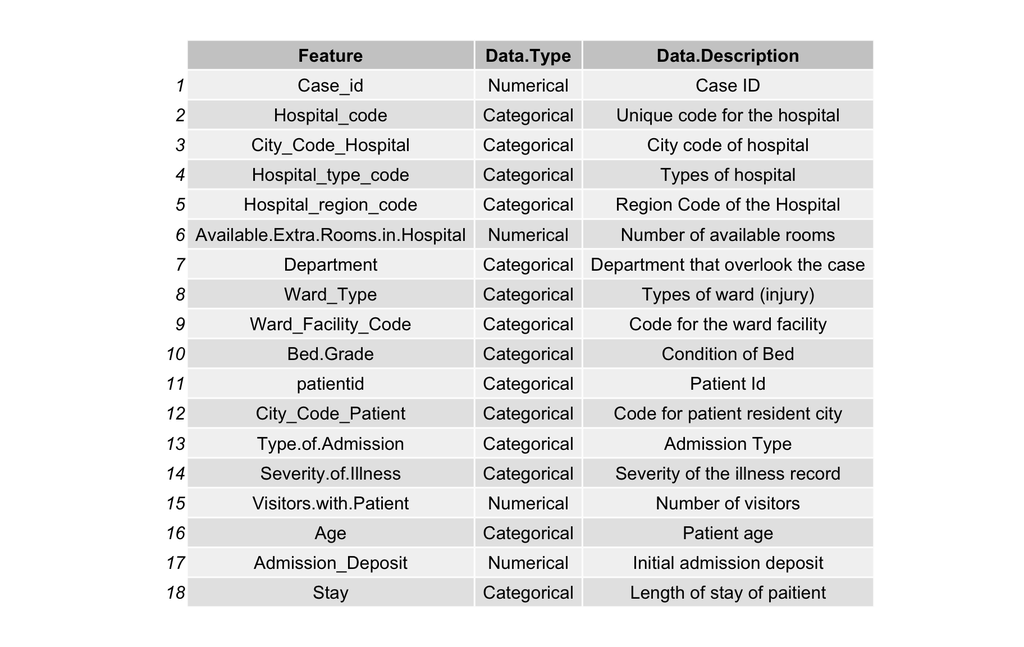

Table 1. Data summary

```r
data_summary <- read.csv("Data_type_summary.csv")

myTable = tableGrob(data_summary)

grid.arrange(myTable, nrow = 1)
```

# 3 Initial Data Analysis

## 3.1 Data Cleaning

### 3.1.1 Remove unnecessary feature and change data types

The first step for initial data analysis is to remove unnecessary features with domain knowledge.

```r
messy1<-messy%>%dplyr::select(-case_id)%>%dplyr::select(-patientid)

messy2<-messy1%>%mutate_at(c("Hospital_code","Hospital_type_code","City_Code_Hospital","Hospital_region_code", "Department","Ward_Type","Ward_Facility_Code","Bed.Grade","City_Code_Patient","Type.of.Admission","Severity.of.Illness","Age","Stay"),as.factor)
messy2<-messy2%>%mutate_at(c("Available.Extra.Rooms.in.Hospital","Visitors.with.Patient","Admission_Deposit"),as.numeric)
```

### 3.1.2 Remove missing values

```r
messy3 <- na.omit(messy2)
sum(!complete.cases(messy3)) # row-wise checking for nulls
```

```
## [1] 0
```

## 3.2 Dataset Visualisation

### 3.2.1 Correlation Heatmap

Correlation heapmap is produced (Figure 1) to explore the relationship between the numerical variables, and the plot shows that all 3 of them appeared not to be highly correlated with each other.

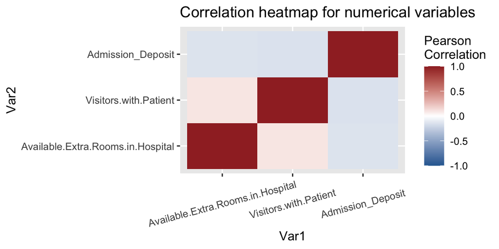

Figure 1. Correlation heatmap

### 3.2.2 Target Class Visualisation

The distribution of classes is shown in Figure 2. Based on the distribution of the class variable, the class imbalance was exposed, and this may lead to a poor prediction performance for under-represented levels of the class.

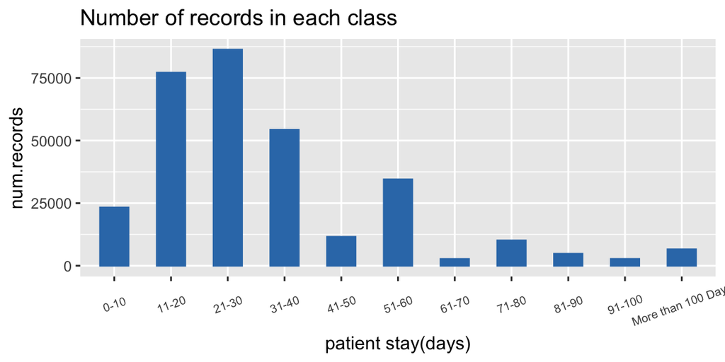

Figure 2. Summary of records count in each class

# 4 Feature Engineering

```r
# dummy matrices
hospital.type <- model.matrix( ~ Hospital_type_code - 1, data = messy3)
hospital.code <- model.matrix( ~ Hospital_code - 1, data = messy3)
city.code.hospital <- model.matrix( ~ City_Code_Hospital - 1, data = messy3)
hospital.region.code <- model.matrix( ~ Hospital_region_code - 1, data = messy3)
department <-  model.matrix( ~ Department - 1, data = messy3)
ward.type <- model.matrix( ~ Ward_Type - 1, data = messy3)
ward.facility.code <- model.matrix( ~ Ward_Facility_Code - 1, data = messy3)
city.code.patient<- model.matrix( ~ City_Code_Patient - 1, data = messy3)
type.of.admission<- model.matrix( ~ Type.of.Admission - 1, data = messy3)
severity.of.illness <- model.matrix( ~ Severity.of.Illness - 1, data = messy3)

# converting to factor (ordinal) to numerical
## bed grade
messy3$Bed.Grade <- as.numeric(messy3$Bed.Grade)
## age
lookup = data.frame(Age=levels(messy3$Age), AgeNumeric=c(1:10))
age = merge(messy3, lookup, by="Age")$AgeNumeric

# creating a new dataframe include all new created dummy variables and all other variables
data <- data.frame(hospital.type, hospital.code, city.code.hospital, hospital.region.code, available.extra.rooms.in.hospital = messy3$Available.Extra.Rooms.in.Hospital, department, ward.type, ward.facility.code, bed.grad = messy3$Bed.Grade, city.code.patient, type.of.admission, severity.of.illness, visitors.with.patient = messy3$Visitors.with.Patient, age, admission.deposit = messy3$Admission_Deposit, Stay=messy3$Stay)

# checking
# head(data)
```

```r
labels1<-c("0-10","11-20","21-30")
labels2<-c("31-40","41-50","51-60","71-80","81-90","91-100","More than 100 Days")

messy4<-messy3%>%mutate_at(c("Stay"),as.character)
# class label 0 for stay "0-30" days and class label 1 for stay "above 30" days
messy4<-messy4%>%mutate(Stay = ifelse(Stay %in% labels1,0,1))
messy4$Stay <- as.factor(messy4$Stay)

dummy4<-data%>%mutate_at(c("Stay"),as.character)
# class label 0 for stay "0-30" days and class label 1 for stay "above 30" days
dummy4<-dummy4%>%mutate(Stay = ifelse(Stay %in% labels1,0,1))
dummy4$Stay <- as.factor(dummy4$Stay)
```

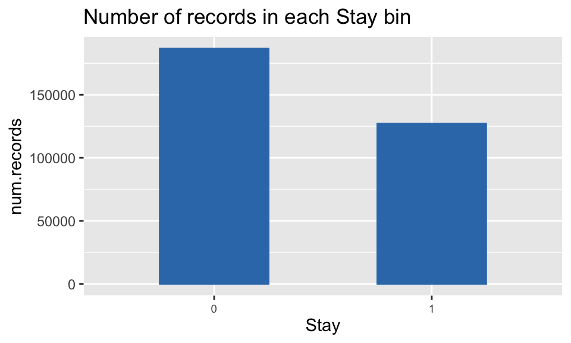

Figure 3. Class distribution after binary transformation

# 5 Classification Algorithms

```r
inTrain <- createDataPartition(messy4$Stay, p = .75)[[1]] # by default it's a stratified split
datatrain <- messy4[ inTrain, ]
datatest  <- messy4[-inTrain, ]

datatrain_dummy <- dummy4[ inTrain, ]
datatest_dummy <- dummy4[ -inTrain, ]

# Separate the feature and the label
train <- datatrain[,-16]
test  <- datatest[,-16]
stay.train <- datatrain[,16]
stay.test <- datatest[,16]

train_dummy <- datatrain_dummy[,-119]
test_dummy  <- datatest_dummy[,-119]
stay.train_dummy <- datatrain_dummy[,119]
stay.test_dummy <- datatest_dummy[,119]
```

## 5.1 Logistic regression

### 5.1.1 Methodology

A logistic regression model is useful for binary classification issues, thus, logistic regression is selected to be one of the algorithms for patients’ LOS. Logistic regression is based on a linear function. It uses log transformation that allows logistic regression to mapping the function to output a bounded estimated probability between 0 and 1. The probability estimate of logistic regression as an output can be used to estimate the confidence of the predicted value to be an actual value, when given a new input. In the current study, 0.5 was set to be the linear decision boundary. Thus, if the hypothesis is greater than 0.5, the prediction belongs to the 1 class; if the hypothesis function is less than 0.5, the prediction belongs to the 0 class.

### 5.1.2 Feature selection

In order to find the best model, a forward stepwise feature selection was utilised. The forward selection begins with a null model and iteratively adds new features to it in order to improve the model performance. The selection process will stop when the added feature no longer improves the model performance. The model performance is evaluated through Akaike Information Criterion (AIC), AIC estimates the information lost by a given model and a lower AIC value indicates better model performance.

```r
# Run algorithms using 10-fold cross validation
control <- trainControl(method="cv", number=10)

# Feature selection process and print out important features for the model
if (longrun){
  M0 <- glm(Stay ~ 1,data = datatrain,family=binomial(link='logit'))
  M1 <- glm(Stay~.,data = datatrain,family = binomial(link='logit'))
  M1.forw <- step(M0, scope = list(lower = M0,
       upper = M1),direction = "forward", k = 2)

  summary(M1.forw)
}
```

### 5.1.3 Final Model And Result

The final model is obtained through a 10-fold cross validation to ensure generalisability of the results and the model consists of the following features: “Visitors.with.Patient” + “Ward_Type” + “Hospital_code” + “Type.of.Admission” + “Available.Extra.Rooms.in.Hospital” + “Severity.of.Illness” + “Age” + “City_Code_Patient”+ “Department” + “Admission_Deposit”.

```r
model_cv <- caret::train(Stay ~ Visitors.with.Patient + Ward_Type + Hospital_code +
    Type.of.Admission + Available.Extra.Rooms.in.Hospital + Severity.of.Illness +
    Age + City_Code_Patient + Department + Admission_Deposit, data = datatrain, method = "glm",trControl = control)

glm_cv.prob <- predict(model_cv, newdata = datatest,type = "prob")
glm_cv.result <- ifelse(glm_cv.prob[2]>0.5,1,0)

glm_cv.result <- confusionMatrix(stay.test, factor(glm_cv.result))
glm_cv.result$overall['Accuracy']
```

```
##  Accuracy
## 0.7777891
```

```r
glm_cv.result$byClass
```

```
##          Sensitivity          Specificity       Pos Pred Value
##            0.7653637            0.8070784            0.9033965
##       Neg Pred Value            Precision               Recall
##            0.5933675            0.9033965            0.7653637
##                   F1           Prevalence       Detection Rate
##            0.8286714            0.7021339            0.5373878
## Detection Prevalence    Balanced Accuracy
##            0.5948526            0.7862210
```

```r
model <- glm(Stay ~ Visitors.with.Patient + Ward_Type + Hospital_code +
    Type.of.Admission + Available.Extra.Rooms.in.Hospital + Severity.of.Illness +
    Age + City_Code_Patient + Department + Admission_Deposit, data = datatrain,family="binomial" )
glm.result <- predict(model, newdata = datatest, type = "response")
#ROC for glm
roc.glm <- roc(datatest$Stay, as.numeric(glm.result))
```

The final model is used to predict unlabeled vectors, with the probability cut off of 0.5, the model performance is then evaluated based on its accuracy score, F1 score, specificity and balanced accuracy score. The accuracy of logistic regression was 77.78%, while the F1-score was 82.86%. The balanced accuracy of the logistic regression model was similar to the accuracy indicating that the model produces equally accurate predictions on both classes and the specificity acquired an accuracy of 80.71%.

## 5.2 XGBoost

### 5.2.1 Methodology

Boosting algorithms seek to improve the prediction accuracy by training a series of base models iteratively, and in each iteration, the model will compensate for the weaknesses of its predecessors. (Zhang, 2019). Extreme Gradient Boosting (XGBoost) is an optimised distributed gradient boosting which attempts to minimise the loss of a model while iterating the base model and using a gradient-descent like procedure. (Brownlee, 2020). Since we are dealing with a binary classification model in this report, the base model in our boosting algorithm will be a gradient boosted tree. More specifically, the tree is grown sequentially to minimise the misclassification from the previous tree.

```r
# preparing matrix for XGBoost
dtrain <- xgb.DMatrix(data =  as.matrix(train_dummy), label = as.numeric(stay.train_dummy)-1)
dtest <- xgb.DMatrix(data = as.matrix(test_dummy), label = as.numeric(stay.test_dummy)-1)
labels <- as.numeric(stay.train_dummy)-1
ts_label <- as.numeric(stay.test_dummy)-1


### Default Model
#default parameters
params <- list(booster = "gbtree", objective = "binary:logistic", eta=0.01, gamma=0, max_depth=5, min_child_weight=1, subsample=1, colsample_bytree=1)

#first default - model training
xgb1 <- xgb.train (params = params, data = dtrain, nrounds = 66, watchlist = list(val=dtest,train=dtrain), print_every_n = 10, early_stopping_rounds = 10, maximize = F , eval_metric = "error")

#model prediction
xgbpred <- predict(xgb1,dtest)
xgbpred <- ifelse (xgbpred > 0.5,1,0)
# accuracy = 100-0.200261 = 80%


### Default model evaluation
#confusion matrix
acc <- confusionMatrix(as.factor(xgbpred), as.factor(ts_label))[[3]][1]
#Accuracy - 79.3%`

#feature variable importance plot
mat <- xgb.importance (feature_names = colnames(as.matrix(train_dummy)),model = xgb1)
# xgb.plot.importance (importance_matrix = mat[1:20])
```

### 5.2.2 Hyperparameter Tuning

*gbtree* booster is selected as our base model to solve a classification problem, and a hyperparameter tuning process was taken in order to maximise the performance of our XGBoost.

- *eta* is one of the most important parameters. It controls the learning rate, where lower eta leads to slower computation yet more careful search of the maxima. To set a smaller eta, the *nrounds* parameter needs to be set higher to avoid termination of search before reaching the maximum point. (tune range: 0.01 - 0.3)
- *max_depth* parameter controls the depth of a tree. Depth of the tree determines the complexity of the model, and a deeper model is more likely to be overfitting potentially. Therefore, optimisation of the max depth parameter is crucial to avoid overfitting issues. (tune range: 3 - 10)
- *Min_child_weight* is the minimum number of instances needed in a child node. Having the child weight stops the tree from splitting infinitely, and in return, controls overfitting. (tune range: 1 - 5)
- *Subsample* and *colsample_bytree* are controlling the number of samples of features supplied to a tree, which again prevent overfitting. (tune range: 0.5 - 1)

Learner is created from the MLR package, which will be used in the tuneParams function. Random search is applied to search for 20 different parameter combinations randomly from the specified tuning range and tested on the training set using 5 fold cross validation. The best parameter set is defined as the one that returns the highest accuracy. Eta is not included in the random search process, but rather is tuned manually within the range 0.01 - 0.3.

```r
if (longrun){

#create learner
lrn <- makeLearner("classif.xgboost",predict.type = "response")
lrn$par.vals <- list(objective="binary:logistic", eval_metric="error", nrounds=70L, eta=0.05)

#set parameter space
params <- makeParamSet(makeDiscreteParam("booster",values = c("gbtree")), makeIntegerParam("max_depth",lower = 3L,upper = 10L), makeNumericParam("min_child_weight",lower = 1L, upper = 5L), makeNumericParam("subsample",lower = 0.5,upper = 1), makeNumericParam("colsample_bytree",lower = 0.5,upper = 1))

#set resampling strategy
rdesc <- makeResampleDesc("CV", stratify = T,iters=5L)

# Random search handler
# search strategy
ctrl <- makeTuneControlRandom(maxit = 20L) # randomly search for 10 different sets of parameters


#create tasks
train_dummy_full = train_dummy
test_dummy_full = test_dummy

train_dummy_full['Stay'] = stay.train_dummy
test_dummy_full['Stay'] = stay.test_dummy

traintask <- makeClassifTask(data = train_dummy_full,target = "Stay")
testtask <- makeClassifTask(data = test_dummy_full,target = "Stay")

# parameter tuning
mytune <- tuneParams(learner = lrn, task = traintask, resampling = rdesc, measures = acc, par.set = params, control = ctrl, show.info = T)


# Hyperparameter tuning results
mytune$y #0.7962
mytune$x
# $booster ="gbtree"
# $max_depth = 8
# $min_child_weight = 1.895179
# $subsample = 0.9189249
# $colsample_bytree = 0.5746373

}
```

### 5.2.3 Final Model And Result

```r
# the actual model traning process
if (longrun){
#set hyperparameters
lrn_tune <- setHyperPars(lrn, par.vals = mytune$x)

#train model
xgmodel <- train(learner = lrn_tune,task = traintask)

#predict model
xgpred <- predict(xgmodel,testtask)
}

# manually pass in best hyperparameters so to save running time
params_final <- list(booster = "gbtree", objective = "binary:logistic", eta=0.05, gamma=0, max_depth=10, min_child_weight = 1.120319, subsample=0.8879472, colsample_bytree=0.7780208)
xgb_final <- xgb.train(params = params_final, data = dtrain, nrounds = 66, watchlist = list(val=dtest,train=dtrain), print.every.n = 10, early.stop.round = 10, maximize = F , eval_metric = "error")
xgbpred_final <- predict(xgb_final, dtest)
```

```r
#output a confusion matrix
result <- confusionMatrix(as.factor(as.numeric(xgbpred_final > 0.5)), as.factor(ts_label))
result$overall['Accuracy']
```

```
##  Accuracy
## 0.7974964
```

```r
result$byClass
```

```
##          Sensitivity          Specificity       Pos Pred Value
##            0.9504982            0.5728534            0.7656522
##       Neg Pred Value            Precision               Recall
##            0.8874104            0.7656522            0.9504982
##                   F1           Prevalence       Detection Rate
##            0.8481204            0.5948526            0.5654064
## Detection Prevalence    Balanced Accuracy
##            0.7384637            0.7616758
```

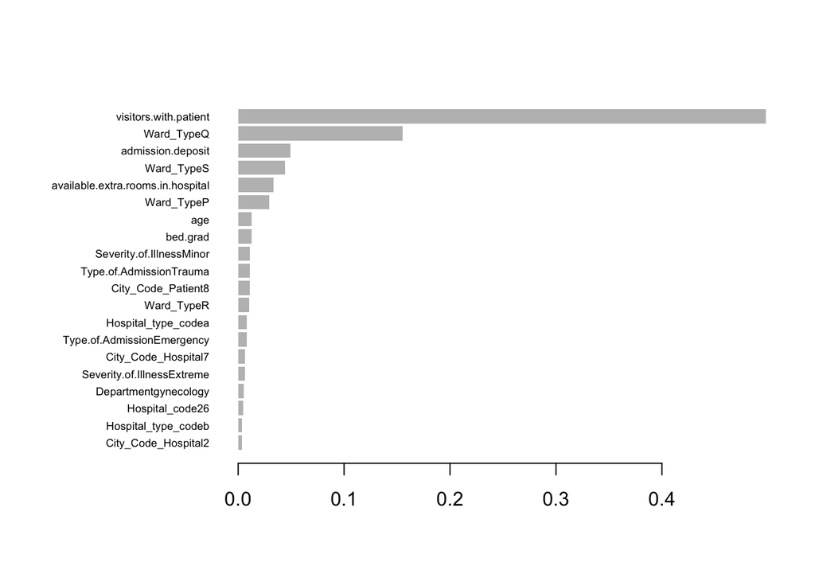

Figure 4. Feature importance plot for XGBoost

```r
roc.xgboost <- roc(ts_label, xgbpred_final)

mat <- xgb.importance (feature_names = colnames(as.matrix(train_dummy)),model = xgb_final)
xgb.plot.importance (importance_matrix = mat[1:20])
```

The model is applied on the testing set to assess the prediction performance of XGBoost on the unlabelled data. The accuracy on the test set is 79.75% and the specificity is 57.29%. Feature importance is generated automatically by XGBoost showing features from most important to least top to bottom.

## 5.3 Random Forest

### 5.3.1 Methodology

Random Forest is chosen to be our third classification model to predict the patient stay in the hospital. Random Forest is a supervised machine learning algorithm that combines multiple decision trees into one single result (Sklearn.ensemble.randomforestclassifier. (n.d.)). It generates a random subset of the features and grow an uncorrelated forest, in other words, it produces aggregated predictions to result in more precise and robust outcomes .Another benefit random forest provides is that it tends not to overfit and ability to handle non-linear numeric and categorical predictors.

### 5.3.2 Hyperparameter Tuning

```r
# hyperparameter tuning
hyper_grid <- expand.grid(
  mtry       = seq(3,15, by = 3),
  num.trees = seq(300,800, by =100),
  accuracy   = 0
)


for(i in 1:nrow(hyper_grid)) {
    # train modelÍÍz
    rf <- ranger(
      formula        = Stay ~ .,
      data           = datatrain,
      num.trees      = hyper_grid$num.trees[i],
      mtry           = hyper_grid$mtry[i],
      importance = 'impurity')
    # add accuracy to grid
    hyper_grid$accuracy[i] <- confusionMatrix(rf$confusion.matrix)$overall['Accuracy']
}

nrow(hyper_grid)
position = which.max(hyper_grid$accuracy)
head(hyper_grid[order(hyper_grid$accuracy,decreasing = TRUE),],5)
```

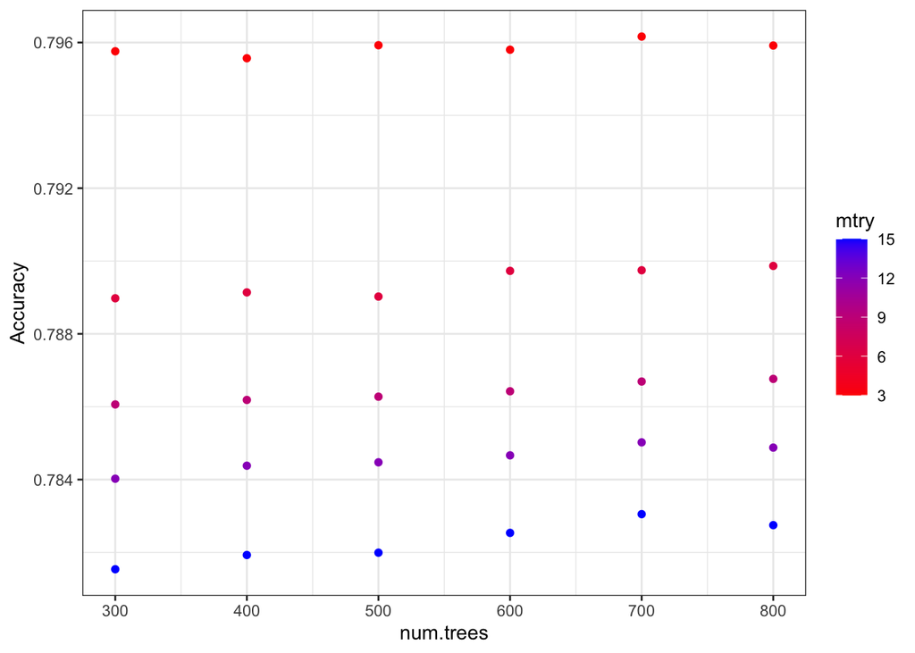

Figure 5. Hyperparameter tuning for random forest

```r
tuning <- ggplot(hyper_grid, aes(x = num.trees, y = accuracy, color = mtry)) +
  geom_point() + theme_bw() + labs(x='num.trees', y="Accuracy")
tuning +scale_color_gradient(low="red", high="blue")
```

```r
#Build model with random forest with ranger

rf.model <- ranger(Stay ~. , data = datatrain, num.trees = 800, importance ='impurity', mtry=3)
rf.test <- predict(rf.model, data = datatest)

# performance on training set
result <- confusionMatrix(rf.model$confusion.matrix)
result$overall['Accuracy']
```

```
##  Accuracy
## 0.7958826
```

```r
# result$byClass
```

### 5.3.3 Final Model And Result

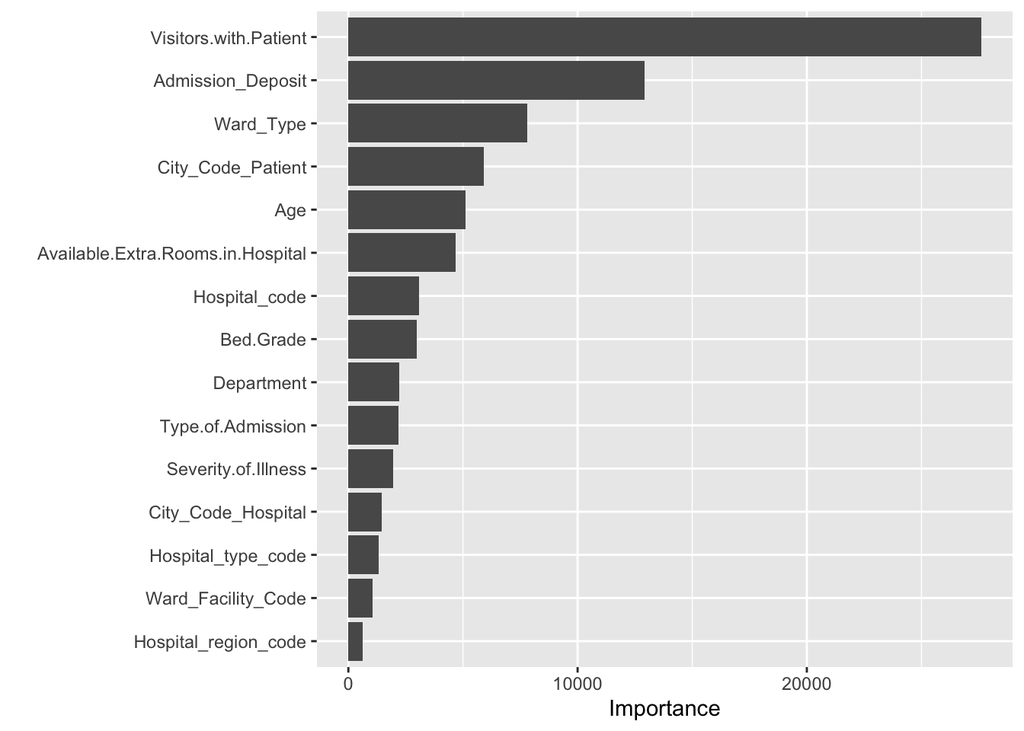

Figure 6. Feature importance plot for random forest

```r
#ranger::importance(rf.model)
require(vip)
v1 <- vip(rf.model, num_features = 15)
v1
```

The final model is then used on the testing set to predict the performance of unseen data. Accuracy, confusion matrix and F1 score were computed to evaluate the model performance. Accuracy was at 79.72% but specificity significantly dropped to 58.12%. This result will be cross compared with the rest of the 3 classification models to compare testing performance.

```r
CM = table(rf.test$predictions,datatest$Stay)
confusionMatrix(CM)$overall['Accuracy']
```

```
##  Accuracy
## 0.7971905
```

```r
confusionMatrix(CM)$byClass
```

```
##          Sensitivity          Specificity       Pos Pred Value
##            0.9443266            0.5811597            0.7679987
##       Neg Pred Value            Precision               Recall
##            0.8766909            0.7679987            0.9443266
##                   F1           Prevalence       Detection Rate
##            0.8470839            0.5948526            0.5617352
## Detection Prevalence    Balanced Accuracy
##            0.7314272            0.7627432
```

```r
# ROC plot
rf.model <- ranger(Stay ~. , data = datatrain, num.trees = 800, importance ='impurity', probability = TRUE ,mtry=3)
rf.test <- predict(rf.model, data = datatest)

roc.rf <- roc(datatest$Stay, as.numeric(rf.test$predictions[,2]))
```

## 5.4 Linear Discriminant Analysis

### 5.4.1 Methodology

Linear discriminant analysis (LDA) is a supervised machine learning technique that models the difference between the classes, aiming to find a linear combination of features that separates two or more classes of events. The established features then can be used as a linear classifier.(Yang, 2020)

LDA is similar to logistic regression, whereas both algorithms explain the target variable by the values of independent predictor variables. However, LDA has a stricter assumption that predictor variables should be normally distributed. In addition, LDA has a closed-form solution (scikit-learn), which means the training and inference time for the model is negligible with a large dataset. However, the downside of the LDA closed-form solution is that the initial parameters of the model only have a little impact on the results, which makes it difficult to improve the model performance.

### 5.4.2 Feature Selection

Just like logistic regression, we used a forward feature selection algorithm on the LDA model to search for the best feature combinations, with a 5-fold cross-validation and 1% improvement in accuracy as the stopping criterion. Based on the forward feature selection, two features were enough to achieve the plateau of accuracy, and adding more features would provide less than 1% increase in accuracy. The final model for LDA consists of the features, Ward_TypeQ and visitors.with.patient.

```r
stepclass(Stay ~ .,data = datatrain_dummy, method = 'lda', direction = 'forward',fold = 5,improvement = 0.01)
```

```
## correctness rate: 0.69218;  in: "visitors.with.patient";  variables (1): visitors.with.patient
## correctness rate: 0.77258;  in: "Ward_TypeQ";  variables (2): visitors.with.patient, Ward_TypeQ
##
##  hr.elapsed min.elapsed sec.elapsed
##       0.000      12.000       3.912
```

```
## method      : lda
## final model : Stay ~ Ward_TypeQ + visitors.with.patient
## <environment: 0x657bd4f98>
##
## correctness rate = 0.7726
```

```r
# Find the probability cut-off when it maximises the combination of specificity and sensitivity
if (longrun){
threshold = seq(0.1,0.9,0.05)
lda.acclist = c()
lda.reclist = c()
lda.prelist = c()
folds <- createFolds(datatrain_dummy$Stay, k=10)
for (t in threshold){
  lda.models <- lapply(folds, function(f) MASS::lda(Stay ~ Ward_TypeQ + visitors.with.patient, data=datatrain_dummy[-f,]))
  lda.preds.cv <- mapply(function(model, f) predict(model,newdata = datatrain_dummy[f,-119])$posterior[,"0"], model = lda.models, f =   folds)
  lda.decision <- lapply(lda.preds.cv, function(f) as.factor(ifelse(f > t, 0, 1)))
  obs <- lapply(folds, function(x) datatrain_dummy$Stay[x])
  lda.metrics <- mapply(function(pred, obs) confusionMatrix(data = pred, reference = obs),
                        pred = lda.decision, obs = obs,
                        SIMPLIFY = FALSE)
  lda.TP <- vapply(lda.metrics, function(cm) cm[["table"]][1, 1], numeric(1))
  lda.FP <- vapply(lda.metrics, function(cm) cm[["table"]][1, 2], numeric(1))
  lda.TN <- vapply(lda.metrics, function(cm) cm[["table"]][2, 2], numeric(1))
  lda.FN <- vapply(lda.metrics, function(cm) cm[["table"]][2, 1], numeric(1))
  lda.accuracy <- vapply(lda.metrics, function(cm) cm[["overall"]]["Accuracy"], numeric(1))
  lda.precision = lda.TP/(lda.TP+lda.FP)
  lda.recall = lda.TP/(lda.TP+lda.FN)
  lda.acclist = c(lda.acclist, sum(lda.accuracy)/10)
  lda.reclist = c(lda.reclist, sum(lda.recall)/10)
  lda.prelist = c(lda.prelist, sum(lda.precision)/10)
}
plot(threshold, lda.acclist, type = "b", ylab = "10 fold result",xaxt = "n", ylim = c(0,1))
axis(side = 1, at = seq(0,1,0.05), labels = seq(0,1,0.05))
lines(threshold, lda.reclist,col = 'red',type = "b")
lines(threshold, lda.prelist,col = 'blue',type = "b")
legend(0.1, 0.3, legend=c("accuracy", "recall","precision"), fill = c("black","blue","red"))
}
```

### 5.4.3 Final Model And Result

```r
lda.model.fianl <- MASS::lda(Stay ~ Ward_TypeQ + visitors.with.patient, data=datatrain_dummy)
lda.preds.fianl <- predict(lda.model.fianl,newdata = datatest_dummy[,-119])$posterior[,"0"]

lda.decision.fianl <-  as.factor(ifelse(lda.preds.fianl > 0.5, 0, 1))
lda.result <- confusionMatrix(data = lda.decision.fianl, reference = datatest_dummy[,119])

lda.result$overall['Accuracy']
```

```
##  Accuracy
## 0.7742963
```

```r
lda.result$byClass
```

```
##          Sensitivity          Specificity       Pos Pred Value
##            0.9487839            0.5181072            0.7429813
##       Neg Pred Value            Precision               Recall
##            0.8732566            0.7429813            0.9487839
##                   F1           Prevalence       Detection Rate
##            0.8333647            0.5948526            0.5643866
## Detection Prevalence    Balanced Accuracy
##            0.7596242            0.7334455
```

```r
#ROC for lda
roc.lda <- roc(datatest$Stay, as.numeric(lda.preds.fianl))
```

# 6 Performance Evaluation and Discussion

The current study aimed to establish the best model to accurately predict the new patients, who will stay in the hospital for longer than 30 days through a comparison of the performance of each model. The classification report and ROC-AUC are utilised to estimate the performance of our four models.

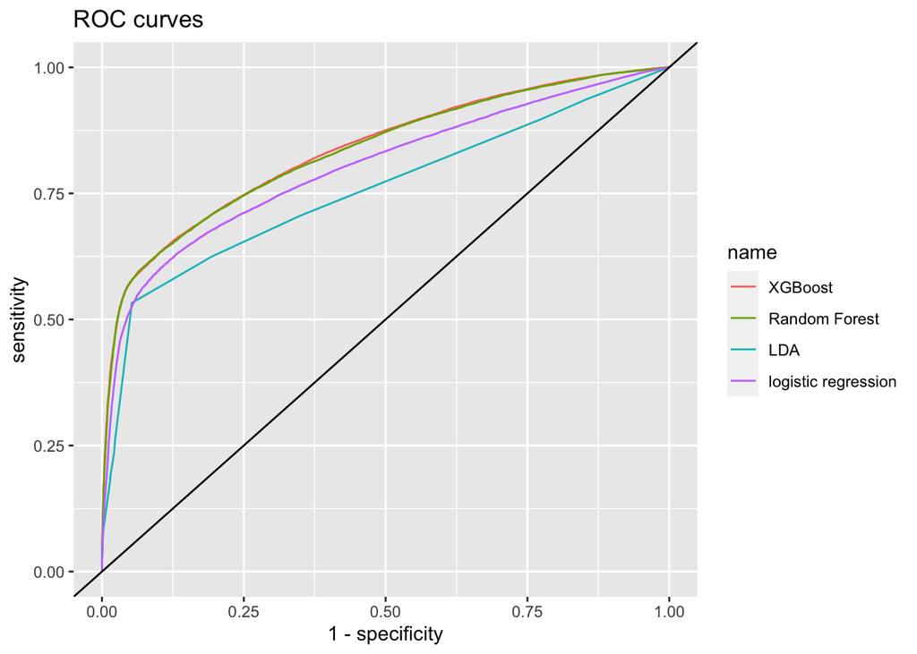

Figure 7. ROC curves for four models

[output not shown]

```r
roc.list <- list(roc.xgboost,roc.rf,roc.lda,roc.glm)
ggroc(roc.list,legacy.axes = TRUE)+geom_abline() +
  ggtitle("ROC curves") +
  scale_color_discrete(labels = c("XGBoost",
                                  "Random Forest",
                                  "LDA",
                                  "logistic regression"))
```

Table 2. AUC for each model

| **Measurement** | **Logistic Regression** | **XGBoost** | **Random Forest** | **Linear Discriminant Analysis** |
| --- | --- | --- | --- | --- |
| Accuracy | 77.78% | 79.75% | 79.72% | 77.43% |
| Sensitivity | 76.54% | 95.05% | 94.43% | 94.88% |
| Specificity | 80.71% | 57.29% | 58.12% | 51.81% |
| F1 Score | 82.87% | 84.81% | 84.71% | 83.34% |

Table 3. Performance metrics for each model

Table 3. shows the comparative classification results across different models with different machine learning algorithms. The XGBoost model produced the highest accuracy (79.75%) for predicting the duration of hospital admission of a patient, while the LDA model produced the lowest accuracy among all the models (77.43%). Despite the low variation in accuracy across different models, the sensitivity and specificity results varied significantly. The logistic regression model was able to make accurate predictions for the patients LOS (> 30 days and < 30 days) proportionally (Sensitivity: 76.54%, Specificity: 80.71%), whereas the other models had significantly lower specificity (below 60%) in comparison to the logistic regression model. Achieving a high specificity is of great importance as specificity indicates the ability to predict the patients with > 30 days LOS, which, in turn, allows hospitals to better allocate resources appropriately to meet the unexpected long stay. In this regard, the logistic regression is chosen for the final model due to its ability to accurately identify the patients’ with longer than 30 days of hospital admission.

The computation time is also an important aspect to consider to determine reasonable run-time to solve a task. Ensemble learning models had a slower run-time compared to the linear-based models. The random forest model had the slowest run time due to a high number of estimators, and the XGBoost was the second slowest. In contrast, Logistic regression has the quickest run-time indicating the highest timewise efficiency as well as the best performance to accurately distinguish the patients, who will stay longer than 30 days in the hospital. The LDA was slightly slower to run than logistic regression because the time complexity of lda is O(nd2) but the time complexity of logistic regression is O(nd).

## 6.1 Limitation

Due to the computational limitation and huge data size, some methods couldn’t be implemented, for example grid search and SVM(support vector machine). Random search is used in the XGBoost method, it is ideal if XGBoost could implement grid search in the future which will potentially find better hyperparameter combinations. In addition to computational limitations, another limitation is unbalanced dataset. After merging the target class “Stay” from multi-class to binary-class, it is still not perfectly balanced. The imbalance problem could potentially leads to poor specificity scores in Random Forest, LDA and XGBoost.

## 6.2 Future Work

In the future, we could implement our model on more powerful machines to enable more efficient calculation. We are also planning to implement more advanced classifiers such as neural networks. This is a much powerful model with numbers of hidden layers to improve calculation which could potentially improve the specificity. For the unbalanced problem, oversampling and downsampling techniques can be employed to obtain more robust results and might achieve high prediction performance. Finally, after using more advanced methods and solving the imbalance problem, we could leave the multi-class variable “Stay” unchanged in the future and do a multi-class classification to give a more precise prediction on days of stay.

# 7 Conclusion

# 8 Reference

- Brownlee, J. (2020, August 14). A gentle introduction to the gradient boosting algorithm for machine learning. Retrieved October 29, 2022, from https://machinelearningmastery.com/gentle-introduction-gradient-boosting-algorithm-machine-learning/
- skikit-learn. (n.d.). Linear and quadratic discriminant analysis. Retrieved October 29, 2022, from https://scikit-learn.org/stable/modules/lda_qda.html
- skikit-learn. (n.d.). Sklearn.ensemble.randomforestclassifier. Retrieved October 29, 2022, from https://scikit-learn.org/stable/modules/generated/sklearn.ensemble.RandomForestClassifier.html
- Yang, X. (2020, May 10). Linear discriminant analysis, explained | by Yang Xiaozhou | towards … Retrieved October 28, 2022, from https://towardsdatascience.com/linear-discriminant-analysis-explained-f88be6c1e00b
- Zhang, Z. (2019, June 17). Boosting algorithms explained - towardsdatascience.com. Retrieved October 28, 2022, from https://towardsdatascience.com/boosting-algorithms-explained-d38f56ef3f30

# 9 Contribution

**Xi Wen Xia:** Finding the dataset in the first place,then coming up with an engaging problem statement and introduction in the project plan, presentation and final report. Xi Wen also writes the future plan section in project plan. On the coding side, Xi Wen codes the random forest model and being responsible for all parts related to random forest in the presentation and final report. Additionally, she checks the rubrics for our deliverables and makes sure the group covers everything.

**Jiahe Chen:** Contributed towards initial dataset research and data description section in initial data analysis. Performed XGBoost classification model, which includes coding and writing up everything related with this model in the final report. Drafted limitation and future work section in the final report. Managed todo list and shared document for the team. Additionally, put together all the codes and writing parts into a single rmd file, edited for consistent structure and better presentation for the final report’s html.

**Andy Lu:** Contributed towards data cleaning, initial analysis and feature engineering with a subgroup of Andy and Duke. Performed logistic regression model coding with model selection and cross-validation. Written the related parts in report and present related parts in group presentation.

**Donguk Kang:** Initial data analysis, missing value treatment for the first stage of the assignments. In preparation of the presentation and report, feature engineering stage which includes dummy variable transformation, and conversion of categorical variable “age” to numerical variable to retain the constraint of the order. Donguk also contributed to summarise the results and compare each model to decide the best model. Presentation slides are put together by Donguk as well.

**Xianyuan Zeng:** Responsible for the challenge&approach section in the IDA stage and the coded for LDA model along with all related writing in the final report. SVM model is also implemented but due to hardware limitation, it is not included in the final report.

**Jason Huang:** Coded the ROC-AUC graph and wrote the IDA, limitation, future work and conclusion sections in the final report. I participated in all group meetings and discussions.